# Stat Rethinking Chapter 4

# Set up

Load required libraries

```r
library(rethinking, quietly = TRUE)
library(tidyverse, quietly = TRUE)
library(DT, quietly = TRUE)
```

# Chapter 4

## Q4H1

The weights below were recorded from the !Kung census but heights were not recorded for these individuals. Provide predicted heights and 89% intervals (either HPDI or PI) for each of these individuals. That is, fill the table using model based predictions.

```r
kung_extra <- data.frame(i=1:5,
                         weight=c(46.95, 43.72, 64.78, 32.59, 54.63),
                         height=rep(NA,5),
                         pi_89_lower=rep(NA,5),
                         pi_89_upper=rep(NA,5))
DT::datatable(kung_extra)
```

|  | i | weight | height | pi_89_lower | pi_89_upper |
| --- | --- | --- | --- | --- | --- |
| 1 | 1 | 46.95 |  |  |  |
| 2 | 2 | 43.72 |  |  |  |
| 3 | 3 | 64.78 |  |  |  |
| 4 | 4 | 32.59 |  |  |  |
| 5 | 5 | 54.63 |  |  |  |

Make a model using adults:

```r
data(Howell1)
d_adults <- Howell1[Howell1$age >= 18,]

m4h0_flist <- alist(
        height ~ dnorm( mu , sigma ) ,
        mu <- a + b*weight ,
        a ~ dnorm( 178 , 30 ) ,
        b ~ dnorm( 0 , 10 ) ,
        sigma ~ dunif( 0 , 50 )
)

m4h0 <- rethinking::map( m4h0_flist , data=d_adults )
```

Now do the predictions:

```r
m4h0.mu <- link( m4h0 , data=list(weight=kung_extra$weight ))
```

```
## [ 100 / 1000 ]
[ 200 / 1000 ]
[ 300 / 1000 ]
[ 400 / 1000 ]
[ 500 / 1000 ]
[ 600 / 1000 ]
[ 700 / 1000 ]
[ 800 / 1000 ]
[ 900 / 1000 ]
[ 1000 / 1000 ]
```

```r
m4h0.mu.mean <- apply( m4h0.mu , 2 , mean )
m4h0.mu.HPDI <- apply( m4h0.mu , 2 , HPDI , prob=0.89 )
```

Put the predictions in the data frame:

```r
kung_extra$height <- round(m4h0.mu.mean,1)
kung_extra$pi_89_lower <- round(m4h0.mu.HPDI[1,],1)
kung_extra$pi_89_upper <- round(m4h0.mu.HPDI[2,],1)
DT::datatable(kung_extra)
```

|  | i | weight | height | pi_89_lower | pi_89_upper |
| --- | --- | --- | --- | --- | --- |
| 1 | 1 | 46.95 | 156.4 | 155.9 | 156.8 |
| 2 | 2 | 43.72 | 153.5 | 153 | 153.9 |
| 3 | 3 | 64.78 | 172.4 | 171 | 173.9 |
| 4 | 4 | 32.59 | 143.5 | 142.5 | 144.4 |
| 5 | 5 | 54.63 | 163.3 | 162.5 | 164.1 |

## Q4H2

Select rows in Howell dataset below 18 years of age - should get 192 rows

```r
data("Howell1")
d_u18 <- Howell1[Howell1$age< 18,]
nrow(d_u18)
```

```
## [1] 192
```

### Q4H2a

Fit a linear regression using map, and using the approximate mean for the mean of the intercept prior.

```r
m4h1_flist <- alist(
        height ~ dnorm( mu , sigma ) ,
        mu <- a + b*weight ,
        a ~ dnorm( 100 , 30 ) ,
        b ~ dnorm( 0 , 10 ) ,
        sigma ~ dunif( 0 , 50 )
)

m4h1 <- rethinking::map( m4h1_flist , data=d_u18 )
```

View the coefficients:

```r
precis( m4h1 )
```

```
##        Mean StdDev  5.5% 94.5%
## a     58.32   1.40 56.09 60.55
## b      2.72   0.07  2.61  2.83
## sigma  8.44   0.43  7.75  9.13
```

So for every 10 units increase in weight, the child gets 27.2 units taller.

### Q42Hb

Plot the raw data plus the MAP regression line and 89% HPDI for the mean. Also superimpose the 89% HPDI for the predicted heights.

```r
#use link to generate MAP line and its HPDI
m4h1.weight.seq <- seq( from=2, to=50 , length.out=49 )
m4h1.mu <- link( m4h1 , data=list(weight=m4h1.weight.seq ))
```

```
## [ 100 / 1000 ]
[ 200 / 1000 ]
[ 300 / 1000 ]
[ 400 / 1000 ]
[ 500 / 1000 ]
[ 600 / 1000 ]
[ 700 / 1000 ]
[ 800 / 1000 ]
[ 900 / 1000 ]
[ 1000 / 1000 ]
```

```r
m4h1.mu.mean <- apply( m4h1.mu , 2 , mean )
m4h1.mu.HPDI <- apply( m4h1.mu , 2 , HPDI , prob=0.89 )

#use sim to generate HPDI for predicted heights
m4h1.sim.height <- sim( m4h1 , data=list(weight=m4h1.weight.seq ) )
```

```
## [ 100 / 1000 ]
[ 200 / 1000 ]
[ 300 / 1000 ]
[ 400 / 1000 ]
[ 500 / 1000 ]
[ 600 / 1000 ]
[ 700 / 1000 ]
[ 800 / 1000 ]
[ 900 / 1000 ]
[ 1000 / 1000 ]
```

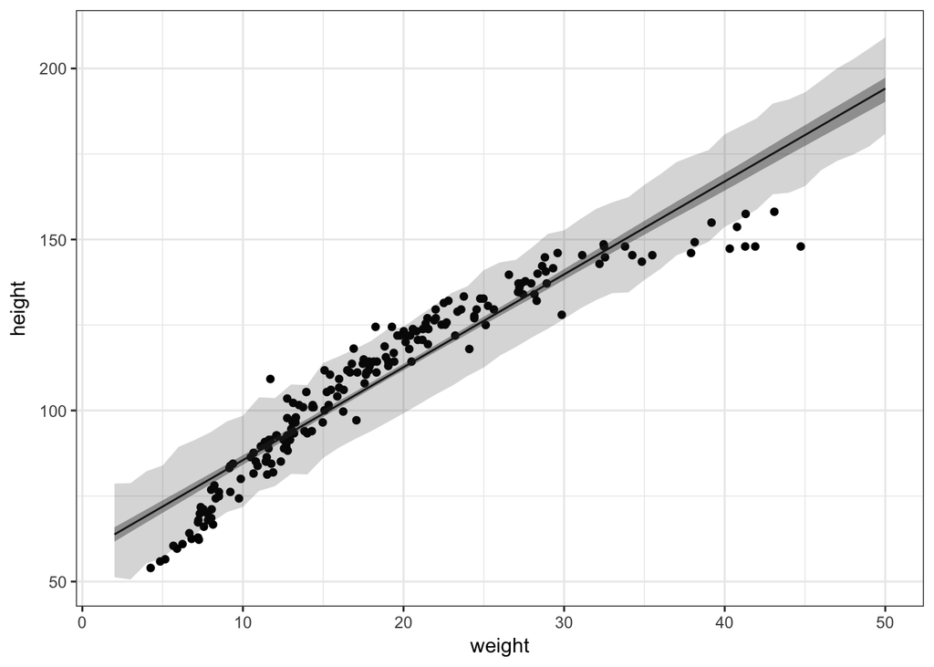

```r
m4h1.height.HPDI <- apply( m4h1.sim.height , 2 , HPDI , prob=0.89 )

#make a data frame of model predictions for plotting
m4h1_model_plot_dat <- data.frame(weight=m4h1.weight.seq,
                             height=m4h1.mu.mean,
                             mu_pi_lower=m4h1.mu.HPDI[1,],
                             mu_pi_upper=m4h1.mu.HPDI[2,],
                             height_pi_lower=m4h1.height.HPDI[1,],
                             height_pi_upper=m4h1.height.HPDI[2,])

#do plot with ggplot2
library(ggplot2)
ggplot(d_u18, aes(weight, height)) +
    geom_point() +
    geom_line(data=m4h1_model_plot_dat) +
    geom_ribbon(data=m4h1_model_plot_dat, aes(x=weight, ymin=mu_pi_lower, ymax=mu_pi_upper),
                alpha=0.4) +
    geom_ribbon(data=m4h1_model_plot_dat, aes(x=weight, ymin=height_pi_lower, ymax=height_pi_upper),
                alpha=0.2) +
    theme_bw()
```

## Q4H3

Fit a model including the log term:

```r
m4h3_flist <- alist(
        height ~ dnorm( mu , sigma ) ,
        mu <- a + b*log(weight) ,
        a ~ dnorm( 178 , 100 ) ,
        b ~ dnorm( 0 , 100 ) ,
        sigma ~ dunif( 0 , 50 )
)

m4h3 <- rethinking::map( m4h3_flist , data=Howell1 )
```

Look at coefficients:

```r
precis(m4h3)
```

```
##         Mean StdDev   5.5%  94.5%
## a     -23.78   1.33 -25.92 -21.65
## b      47.08   0.38  46.46  47.69
## sigma   5.13   0.16   4.89   5.38
```

For every log unit of weight, height increases by 47 units.

### Q4H3b

```r
#use link to generate MAP line and its HPDI
m4h3.weight.seq <- seq( from=2, to=65 , length.out=64 )
m4h3.mu <- link( m4h3 , data=list(weight=m4h3.weight.seq ))
```

```
## [ 100 / 1000 ]
[ 200 / 1000 ]
[ 300 / 1000 ]
[ 400 / 1000 ]
[ 500 / 1000 ]
[ 600 / 1000 ]
[ 700 / 1000 ]
[ 800 / 1000 ]
[ 900 / 1000 ]
[ 1000 / 1000 ]
```

```r
m4h3.mu.mean <- apply( m4h3.mu , 2 , mean )
m4h3.mu.HPDI <- apply( m4h3.mu , 2 , HPDI , prob=0.97 )

#use sim to generate HPDI for predicted heights
m4h3.sim.height <- sim( m4h3 , data=list(weight=m4h3.weight.seq ) )
```

```
## [ 100 / 1000 ]
[ 200 / 1000 ]
[ 300 / 1000 ]
[ 400 / 1000 ]
[ 500 / 1000 ]
[ 600 / 1000 ]
[ 700 / 1000 ]
[ 800 / 1000 ]
[ 900 / 1000 ]
[ 1000 / 1000 ]
```

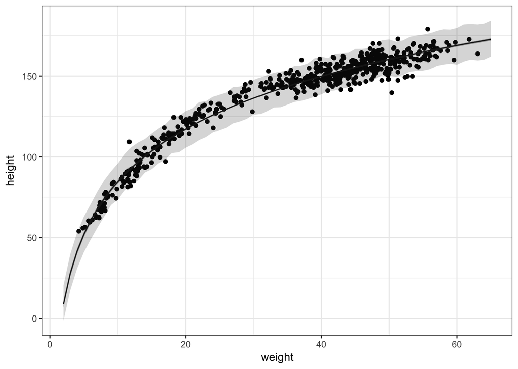

```r
m4h3.height.HPDI <- apply( m4h3.sim.height , 2 , HPDI , prob=0.97 )

#make a data frame of model predictions for plotting
m4h3_model_plot_dat <- data.frame(weight=m4h3.weight.seq,
                             height=m4h3.mu.mean,
                             mu_pi_lower=m4h3.mu.HPDI[1,],
                             mu_pi_upper=m4h3.mu.HPDI[2,],
                             height_pi_lower=m4h3.height.HPDI[1,],
                             height_pi_upper=m4h3.height.HPDI[2,])

#do plot with ggplot2
library(ggplot2)
ggplot(Howell1, aes(weight, height)) +
    geom_point() +
    geom_line(data=m4h3_model_plot_dat) +
    geom_ribbon(data=m4h3_model_plot_dat, aes(x=weight, ymin=mu_pi_lower, ymax=mu_pi_upper),
                alpha=0.4) +
    geom_ribbon(data=m4h3_model_plot_dat, aes(x=weight, ymin=height_pi_lower, ymax=height_pi_upper),
                alpha=0.2) +
    theme_bw()
```